# R Notebook

Here, we want to identify the potential changes in phosphorylation which may occur following inhibition of EGFR as per the Orre et al (2018) ‘SubCellBarCode’ paper (https://www.cell.com/molecular-cell/pdfExtended/S1097-2765(18)31005-0), in which they used gefitinib to inhibit EGFR in a 746-750 del EGFR mutant cell line (HCC827).

In Zhang et al (2017; https://www.mcponline.org/content/16/5/891/tab-figures-data), they used EGFR inhibitors on a variety of backgrounds, including PC9 which is also 746-750 del. Unfotunately, they didn’t use Gefitinib but rather erlotinib, which appears to be a similar first generation EGFR tyrosine kinase inhibitor (TKI) so this seems close enough.

```r
library(tidyverse)
```

[output not shown]

[output cut: 199 more lines]

For PC9, the SILAC experiment was conducted such that L=Serum Starved, M=EGF, H=EGF+erlotinib. We are interested in the sites which are erlotinib-sensitive, e.g H/M.

In the paper, they state there are 73 erlotinib-sensitive phosohorylation sites. Le’ts inspect the H/M ratios to see if we can find these as a check we understand their data correctly.

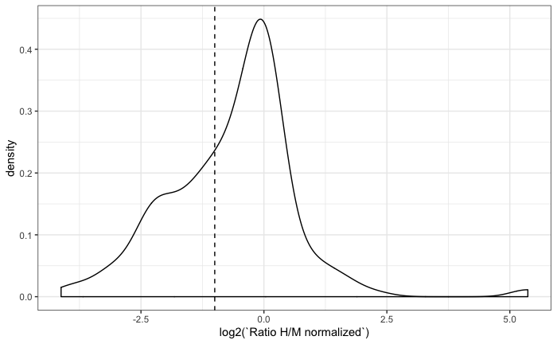

```r
.data %>% ggplot(aes(log2(`Ratio H/M normalized`))) + geom_density() + theme_bw() +
  geom_vline(xintercept=-1, linetype=2)
```

```r
erlotinib_sensitive <- .data %>%
  filter(log2(`Ratio M/L normalized`)<(-1)) %>%
  arrange(`Ratio H/M normalized`)

print(nrow(erlotinib_sensitive))
```

```
[1] 15
```

```r
print(head(erlotinib_sensitive))
```

| Proteins | Positions within proteins | Protein | Protein names | Gene names | Gene | Fasta headers | Localization prob | Amino acid | Position | Gene-PhosphoSite | Sequence window | PEP | Score | Modified sequence | Charge | m/z | Mass error [ppm] | Ratio M/L normalized | Ratio H/L normalized | Ratio H/M normalized | Best localization raw file | Best localization scan number |
| --- | --- | --- | --- | --- | --- | --- | --- | --- | --- | --- | --- | --- | --- | --- | --- | --- | --- | --- | --- | --- | --- | --- |
| P09651;F8W6I7;P09651-2;F8VRQ1;F8VXY0;P09651-3;H0YH80;F8W1S7;F8VSB5 | 347;295;295;282;279;242;166;295;295 | P09651 | Heterogeneous nuclear ribonucleoprotein A1 | HNRNPA1;HNRNPA1;HNRNPA1;HNRNPA1;HNRNPA1;HNRNPA1;HNRNPA1 | HNRNPA1 | >sp\|P09651\|ROA1_HUMAN Heterogeneous nuclear ribonucleoprotein A1 OS=Homo sapiens GN=HNRNPA1 PE=1 SV=5;>tr\|F8W6I7\|F8W6I7_HUMAN Heterogeneous nuclear ribonucleoprotein A1 OS=Homo sapiens GN=HNRNPA1 … | 0.999962 | Y | 347 | HNRNPA1-Y-347 | NFGGRSSGPYGGGGQYFAKPRNQGGYGGSSS | 2.07697e-07 | 133.480 | _SSGPYGGGGQY(ph)FAKPR_ | 2 | 854.8776 | -0.514690 | 0.23901 | 0.108600 | 0.49343 | PC9_2_pY100_Erlot | 4299 |
| Q9ULJ8-3;F8W7J9;Q9ULJ8-4;Q9ULJ8 | 779;757;757;757 | Q9ULJ8-3 | Neurabin-1 | PPP1R9A;PPP1R9A | PPP1R9A | >sp\|Q9ULJ8-3\|NEB1_HUMAN Isoform 3 of Neurabin-1 OS=Homo sapiens GN=PPP1R9A;>tr\|F8W7J9\|F8W7J9_HUMAN Neurabin-1 OS=Homo sapiens GN=PPP1R9A PE=4 SV=1;>sp\|Q9ULJ8-4\|NEB1_HUMAN Isoform 4 of Neurabin-1… | 0.908306 | Y | 779 | PPP1R9A-Y-779 | LCHTVNEHLKETQSQYQALEKKYNKAKKLIK | 5.75312e-02 | 39.163 | _ET(ph)QS(ph)QY(ph)QALEKKYNK_ | 2 | 1049.4202 | 0.041442 | 0.11092 | 0.093349 | 0.74256 | PC9_2_pY100_Erlot | 7731 |
| P07437;F8VW92;F8VYX6;Q5JP53;Q5ST81;F8VUJ7;E7EWR1;Q13885;Q9BVA1;E9PBJ4;Q9BUF5;B3KS31;Q13509;A8K854;P68371;P04350 | 340;340;340;322;268;312;249;340;340;139;340;268;340;268;340;340 | P68371 | Tubulin beta chain;Tubulin beta-2A chain;Tubulin beta-2B chain;Tubulin beta-6 chain;Tubulin beta-3 chain;Tubulin beta-4B chain;Tubulin beta-4A chain | TUBB;TUBB;TUBB;TUBB;TUBB;TUBB;TUBB;TUBB2A;TUBB2B;TUBB;TUBB6;TUBB6;TUBB3;TUBB3;TUBB4B;TUBB4A | TUBB | >sp\|P07437\|TBB5_HUMAN Tubulin beta chain OS=Homo sapiens GN=TUBB PE=1 SV=2;>tr\|F8VW92\|F8VW92_HUMAN Tubulin beta chain OS=Homo sapiens GN=TUBB PE=3 SV=1;>tr\|F8VYX6\|F8VYX6_HUMAN Tubulin beta chain… | 0.817856 | Y | 340 | TUBB-Y-340 | EVDEQMLNVQNKNSSYFVEWIPNNVKTAVCD | 8.58818e-05 | 110.980 | _NSSY(ph)FVEWIPNNVK_ | 2 | 888.9033 | -0.373860 | 0.42821 | 0.397310 | 0.78172 | PC9_2_pY100_Erlot | 8666 |
| B7Z5W1;Q9Y624;B7Z941 | 284;280;231 | B7Z5W1 | Junctional adhesion molecule A | F11R;F11R;F11R | F11R | >tr\|B7Z5W1\|B7Z5W1_HUMAN Junctional adhesion molecule A OS=Homo sapiens GN=F11R PE=2 SV=1;>sp\|Q9Y624\|JAM1_HUMAN Junctional adhesion molecule A OS=Homo sapiens GN=F11R PE=1 SV=1;>tr\|B7Z941\|B7Z941_… | 0.997424 | Y | 284 | F11R-Y-284 | HFDRTKKGTSSKKVIYSQPSARSEGEFKQTS | 5.81936e-04 | 121.360 | _VIY(ph)SQPSAR_ | 2 | 550.7604 | -0.101280 | 0.47645 | 0.415230 | 0.88593 | PC9_1_pY100_Erlot | 2690 |
| E7ESA6;J3QT16;Q05397-5;Q05397;H0YBP1;Q8IYN9;Q05397-2;Q05397-3;Q05397-4;H0YB99;H0YB33 | 441;397;397;397;408;397;216;216;216;210;61 | E7ESA6 | Focal adhesion kinase 1 | PTK2;PTK2;PTK2;PTK2;PTK2;PTK2 | PTK2 | >tr\|E7ESA6\|E7ESA6_HUMAN Focal adhesion kinase 1 OS=Homo sapiens GN=PTK2 PE=4 SV=1;>tr\|J3QT16\|J3QT16_HUMAN Focal adhesion kinase 1 OS=Homo sapiens GN=PTK2 PE=4 SV=1;>sp\|Q05397-5\|FAK1_HUMAN Isofor… | 0.806913 | Y | 441 | PTK2-Y-441 | QGMRTHAVSVSETDDYAEIIDEEDTYTMPST | 3.21425e-13 | 134.470 | _THAVSVSETDDY(ph)AEIIDEEDTYTM(ox)PSTR_ | 3 | 1091.1218 | 0.330010 | 0.45298 | 0.434200 | 1.01740 | PC9_2_pY100_Erlot | 6858 |
| O95297;O95297-2;O95297-4 | 241;240;117 | O95297 | Myelin protein zero-like protein 1 | MPZL1 | MPZL1 | >sp\|O95297\|MPZL1_HUMAN Myelin protein zero-like protein 1 OS=Homo sapiens GN=MPZL1 PE=1 SV=1;>sp\|O95297-2\|MPZL1_HUMAN Isoform 2 of Myelin protein zero-like protein 1 OS=Homo sapiens GN=MPZL1;>sp\|… | 0.856135 | Y | 241 | MPZL1-Y-241 | LVKSLPSGSHQGPVIYAQLDHSGGHHSDKIN | 9.51198e-03 | 35.359 | _SLPSGSHQGPVIY(ph)AQLDHSGGHHSDKINK_ | 4 | 787.3755 | -0.046176 | 0.46756 | 0.594490 | 1.06040 | PC9_3_pY100_Erlot | 4230 |

From here we could either take the top most sensitive and compare to the least sensitive, e.g subset like so. Note that it’s possible for a protein to have sites which are both highly sensitive and highly insensitive so need to start by grouping sites by proteins and identifying the most sensitive site

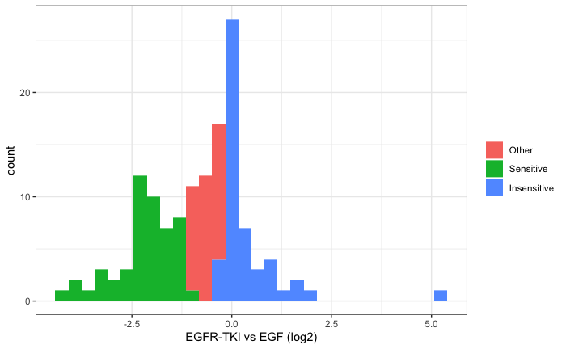

```r
.data_protein <- .data %>%
  group_by(Protein) %>%
  summarise(`Ratio H/M normalized`=min(`Ratio H/M normalized`))

most_sensitive <- .data_protein %>% arrange(`Ratio H/M normalized`) %>%
  pull(Protein) %>% head(50)

least_sensitive <- .data_protein %>% arrange(`Ratio H/M normalized`) %>%
  pull(Protein) %>% tail(50)

.data_protein %>% mutate(sensitive=Protein %in% most_sensitive,
                         insensitive=Protein %in% least_sensitive,
                         label=recode(interaction(sensitive, insensitive),
                                      'FALSE.FALSE'='Other',
                                      'TRUE.FALSE'='Sensitive',
                                      'FALSE.TRUE'='Insensitive')) %>%
  ggplot(aes(log2(`Ratio H/M normalized`), fill=label)) +
  geom_histogram() +
  theme_bw() +
  scale_fill_discrete(name='') +
  xlab('EGFR-TKI vs EGF (log2)')
```